# KumudiniBhave_622_HW2

Kumudini Bhave

May 2, 2020

# **Machine Learning : Classification With Various Models**

## Summary

This is an R Markdown document for performing Classification of the provided color data. We have used different statistical learning solutions for making models and compare dthe accuracy of the same.

```r
knitr::opts_chunk$set(message = FALSE, echo = TRUE)

# Library for loading CSV data
library(RCurl)
# Library for data tidying Library for data structure operations
library(dplyr)
library(knitr)
# Library for plotting
library(ggplot2)
# Library for data display in tabular format library(DT)
library(pander)
library(Amelia)
library(gridExtra)
library(car)
library(caret)
library(pROC)
library(ROCR)
library(naivebayes)
library(rpart)
library(rpart.plot)
library(MASS)
library(e1071)
library(class)

suppressWarnings(suppressMessages(library(recommenderlab)))
```

## Data Loading & Preparation

```r
# Getting data

colordata.giturl <- "https://raw.githubusercontent.com/DataDriven-MSDA/DATA622_ML/master/Homework2/HW2_Data.csv"

colordata <- read.csv(url(colordata.giturl))
head(colordata, 10)
```

```
##     X       Y       label
## 1   5       a        BLUE
## 2   5       b       BLACK
## 3   5       c        BLUE
## 4   5       d       BLACK
## 5   5       e       BLACK
## 6   5       f       BLACK
## 7  19       a        BLUE
## 8  19       b        BLUE
## 9  19       c        BLUE
## 10 19       d        BLUE
```

```r
summary(colordata)
```

```
##        X            Y             label
##  Min.   : 5        a :5         BLACK:22
##  1st Qu.:19        b :5         BLUE :14
##  Median :43        c :5
##  Mean   :38        d :5
##  3rd Qu.:55        e :5
##  Max.   :63        f :5
##               (Other):6
```

We find that the csv imported has leading / trailing whitespace. We remove this and then factor the discrete variables predictor Y and response label

```r
colordata$Y <- trimws(colordata$Y, which = c("both"))
colordata$label <- trimws(colordata$label, which = c("both"))


colordata$Y <- as.factor(colordata$Y)
colordata$label <- as.factor(colordata$label)
summary(colordata)
```

```
##        X      Y       label
##  Min.   : 5   a:6   BLACK:22
##  1st Qu.:19   b:6   BLUE :14
##  Median :43   c:6
##  Mean   :38   d:6
##  3rd Qu.:55   e:6
##  Max.   :63   f:6
```

```r
nrow(colordata)
```

```
## [1] 36
```

```r
ncol(colordata)
```

```
## [1] 3
```

## Data Exploration

We find three columns in this data file, 2 of these viz., X and Y are the predictor variables.While label is discrete response variable. Both are discrete.

```r
colordata$Y <- as.factor(colordata$Y)
colordata$label <- as.factor(colordata$label)


pander(table(colordata$label), caption = "Response Variable : label")
```

Response Variable : label

| BLACK | BLUE |
| --- | --- |
| 22 | 14 |

```r
pander(table(colordata$label)/sum(table(colordata$label)), caption = "Frequency Table : label")
```

Frequency Table : label

| BLACK | BLUE |
| --- | --- |
| 0.6111 | 0.3889 |

```r
pander(summary(colordata))
```

| X | Y | label |
| --- | --- | --- |
| Min. : 5 | a:6 | BLACK:22 |
| 1st Qu.:19 | b:6 | BLUE :14 |
| Median :43 | c:6 | NA |
| Mean :38 | d:6 | NA |
| 3rd Qu.:55 | e:6 | NA |
| Max. :63 | f:6 | NA |

Checking for missing data we fine that we have 100% complete cases.

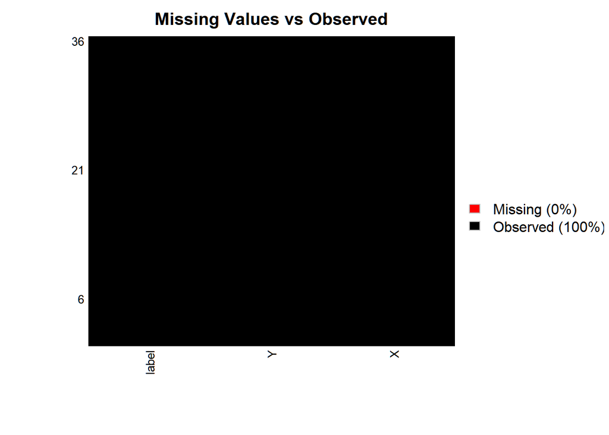

```r
missmap(colordata, legend = TRUE, main = "Missing Values vs Observed", col = c("red", "black"))
```

## Plots For Predictors

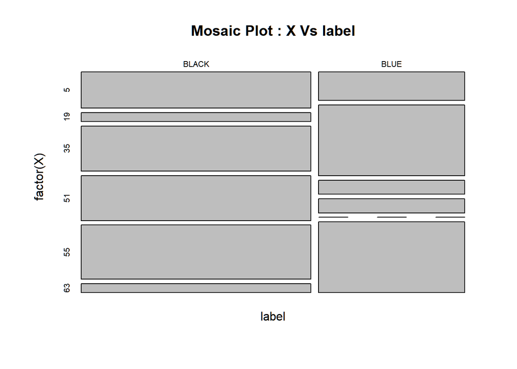

```r
# Predictor Y boxplots
xbox <- ggplot(colordata, aes(factor(X), X, colour = factor(label))) + geom_boxplot() + ggtitle("BoxPlot : X vs label\n")

ybox <- ggplot(colordata, aes(factor(Y), Y, colour = factor(label))) + geom_boxplot() + ggtitle("BoxPlot : Y vs label\n")

xmos <- mosaicplot(~label + factor(X), data = colordata, main = "Mosaic Plot : X Vs label")
```

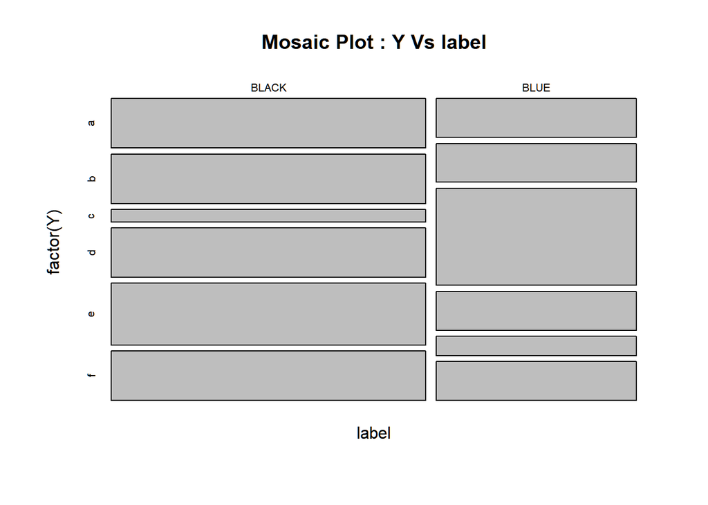

```r
ymos <- mosaicplot(~label + factor(Y), data = colordata, main = "Mosaic Plot : Y Vs label")
```

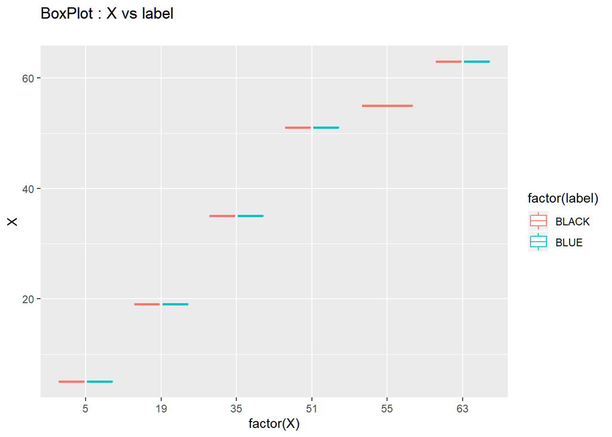

```r
par(mfrow = c(2, 1))
xbox
```

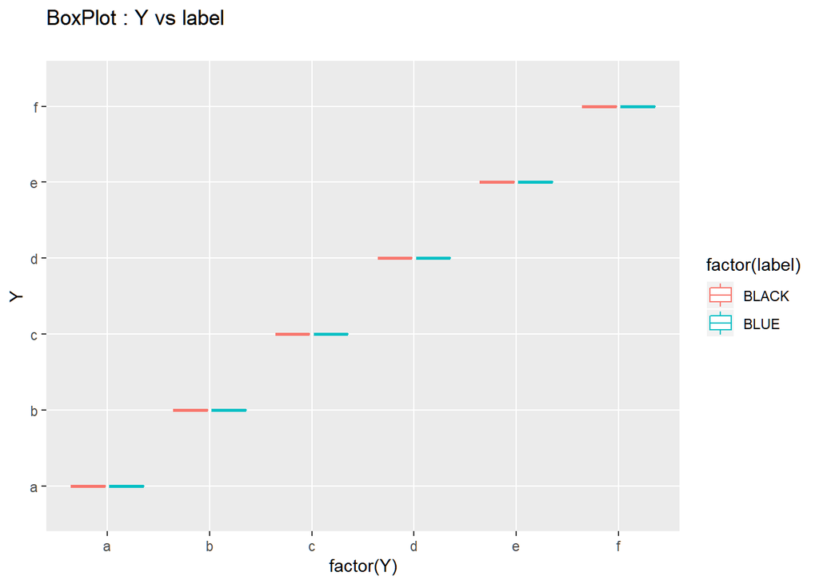

```r
ybox
```

We see that we have six types of observations for X and six types of Y and a combination of these form the observations

We dont see any outliers.

From the mosaic plots we see that c value of Y has less of Black and more of Blue Similarly e of Y has less of Blue

## Model Making

Lets try to make few models by running different statistical learning methods on this data.

We need to form train and test data sets for this.

```r
set.seed(100)
randomobs <- sample(seq_len(nrow(colordata)), size = floor(0.7 * nrow(colordata)))

traincolordata <- colordata[randomobs, ]
testcolordata <- colordata[-randomobs, ]
```

### Helper Function For Performance Metrics

```r
perfmetric <- function(confmattab) {
    confmat <- as.matrix(confmattab)
    print(confmat)

    TP <- confmat[2, 2]
    TN <- confmat[1, 1]
    FP <- confmat[1, 2]
    FN <- confmat[2, 1]

    Sensitivity <- (TP)/(TP + FN)
    Specificity <- (TN)/(FP + TN)

    ErrorRate <- (FP + FN)/(TP + FP + FN + TN)
    Accuracy <- (TP + TN)/(TP + FP + FN + TN)

    FPR <- 1 - Specificity


    perfvec <- c(Sensitivity, FPR, Specificity, ErrorRate, Accuracy)
    return(perfvec)
}
```

### Model : Logistic Regression

```r
traincolor.logistic <- traincolordata

model.logistic <- glm(label ~ ., family = binomial(link = "logit"), data = traincolor.logistic)

summary(model.logistic)
```

```
##
## Call:
## glm(formula = label ~ ., family = binomial(link = "logit"), data = traincolor.logistic)
##
## Deviance Residuals:
##     Min       1Q   Median       3Q      Max
## -1.0427  -0.9207  -0.6827   1.3039   1.7503
##
## Coefficients:
##               Estimate Std. Error z value Pr(>|z|)
## (Intercept) -8.657e-01  1.547e+00  -0.560    0.576
## X            4.123e-03  2.245e-02   0.184    0.854
## Yb           3.135e-01  1.535e+00   0.204    0.838
## Yc           1.829e+01  2.281e+03   0.008    0.994
## Yd           3.002e-01  1.530e+00   0.196    0.844
## Ye          -6.823e-01  1.660e+00  -0.411    0.681
## Yf          -3.519e-01  1.709e+00  -0.206    0.837
##
## (Dispersion parameter for binomial family taken to be 1)
##
##     Null deviance: 33.651  on 24  degrees of freedom
## Residual deviance: 26.748  on 18  degrees of freedom
## AIC: 40.748
##
## Number of Fisher Scoring iterations: 16
```

```r
model.logistic.probtest <- predict(model.logistic, newdata = testcolordata, type = "response")
model.logistic.predtest <- ifelse(model.logistic.probtest > 0.5, "BLUE", "BLACK")

# Confusion Matrix For Model Logistic


model.logistic.cfmat <- table(Predicted = model.logistic.predtest, Actual = testcolordata$label)


metric.logistic <- perfmetric(model.logistic.cfmat)
```

```
##          Actual
## Predicted BLACK BLUE
##     BLACK     6    2
##     BLUE      1    2
```

**Plotting the ROC curve for Model MODEL.LOGISTIC**

```r
model.logistic.roc <- roc(label ~ model.logistic.probtest, data = testcolordata)
model.logistic.auc <- round(auc(model.logistic.roc), 6)

par(mfrow = c(1, 2))

pander(ftable(model.logistic.cfmat))
```

|  | Actual | BLACK | BLUE |
| --- | --- | --- | --- |
| Predicted |  |  |  |
| BLACK |  | 6 | 2 |
| BLUE |  | 1 | 2 |

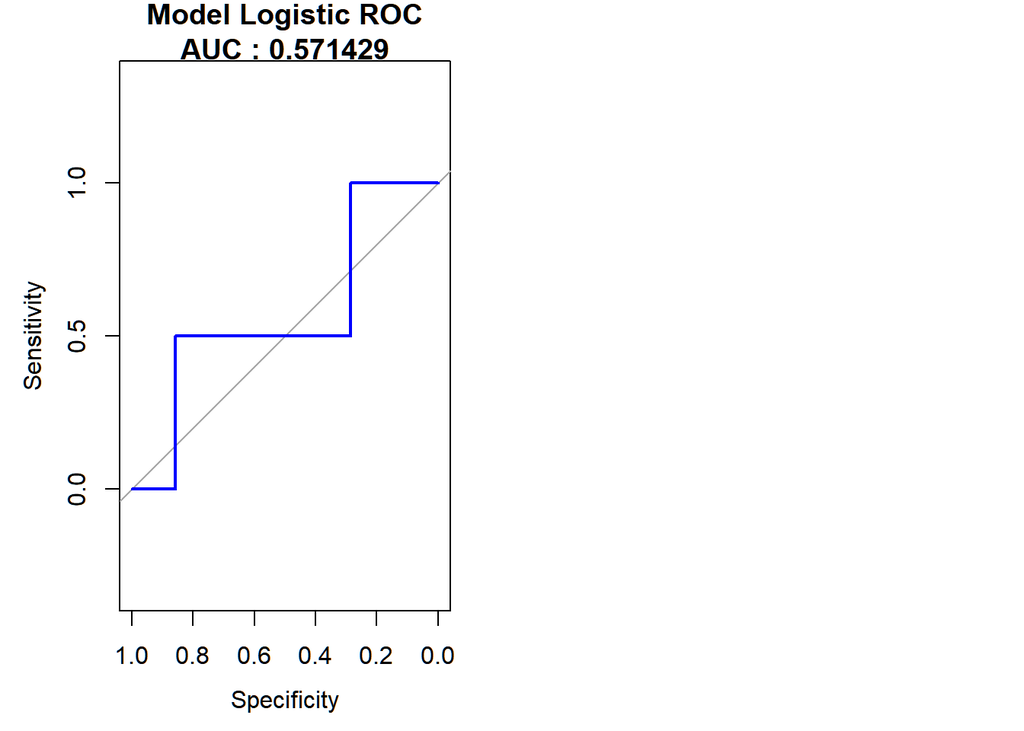

```r
plot(model.logistic.roc, legacy_axes = TRUE, col = "blue", main = paste0("Model Logistic ROC",
    "\n", "AUC : ", model.logistic.auc))


metricmodel <- data.frame(metric.logistic[])
rownames(metricmodel) <- c("Sensitivity", "FPR", "Specificity", "ErrorRate", "Accuracy")
colnames(metricmodel) <- c("Logistic")
```

### Model : Naive Bayes

```r
traincolor.nb <- traincolordata

model.nb <- naiveBayes(label ~ ., data = traincolor.nb, prob = TRUE)

summary(model.nb)
```

```
##           Length Class  Mode
## apriori   2      table  numeric
## tables    2      -none- list
## levels    2      -none- character
## isnumeric 2      -none- logical
## call      5      -none- call
```

```r
model.nb.probtest <- predict(model.nb, newdata = testcolordata, type = "raw")
model.nb.probtest <- as.data.frame(model.nb.probtest)$BLUE

model.nb.predtest <- ifelse(model.nb.probtest > 0.5, "BLUE", "BLACK")


# Confusion Matrix For Model NB


model.nb.cfmat <- table(Predicted = model.nb.predtest, Actual = testcolordata$label)

metric.nb <- perfmetric(model.nb.cfmat)
```

```
##          Actual
## Predicted BLACK BLUE
##     BLACK     6    2
##     BLUE      1    2
```

**Plotting the ROC curve for Model MODEL.NB**

```r
model.nb.roc <- roc(label ~ model.nb.probtest, data = testcolordata)
model.nb.auc <- round(auc(model.nb.roc), 6)

par(mfrow = c(1, 2))

pander(ftable(model.nb.cfmat))
```

|  | Actual | BLACK | BLUE |
| --- | --- | --- | --- |
| Predicted |  |  |  |
| BLACK |  | 6 | 2 |
| BLUE |  | 1 | 2 |

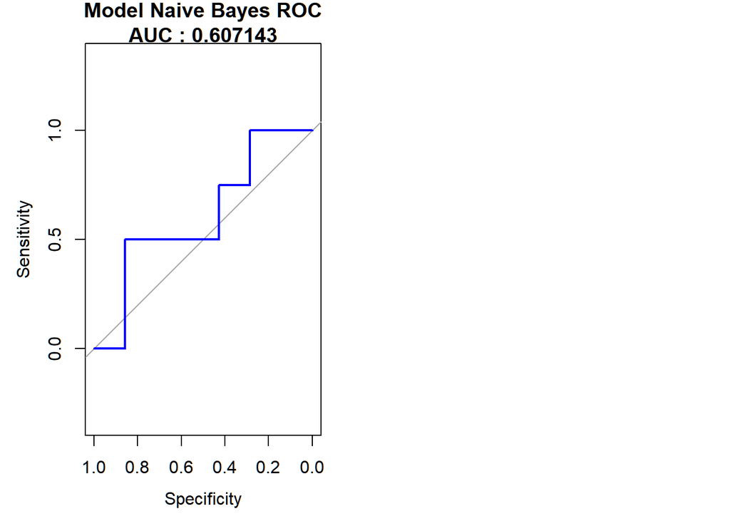

```r
plot(model.nb.roc, legacy_axes = TRUE, col = "blue", main = paste0("Model Naive Bayes ROC",
    "\n", "AUC : ", model.nb.auc))

metricmodel <- cbind(metricmodel, metric.nb[])
```

### Model : LDA

```r
traincolor.lda <- traincolordata

model.lda <- lda(label ~ ., data = traincolor.lda)


summary(model.lda)
```

```
##         Length Class  Mode
## prior    2     -none- numeric
## counts   2     -none- numeric
## means   12     -none- numeric
## scaling  6     -none- numeric
## lev      2     -none- character
## svd      1     -none- numeric
## N        1     -none- numeric
## call     3     -none- call
## terms    3     terms  call
## xlevels  1     -none- list
```

```r
model.lda.probtest <- predict(model.lda, newdata = testcolordata)
model.lda.predtest <- model.lda.probtest$class

lda.post.prob <- as.data.frame(model.lda.probtest$posterior)$BLUE


# Confusion Matrix For Model LDA

model.lda.cfmat <- table(Predicted = model.lda.predtest, Actual = testcolordata$label)

metric.lda <- perfmetric(model.lda.cfmat)
```

```
##          Actual
## Predicted BLACK BLUE
##     BLACK     6    2
##     BLUE      1    2
```

**Plotting the ROC curve for Model MODEL.LDA**

```r
model.lda.roc <- roc(label ~ lda.post.prob, data = testcolordata)
model.lda.auc <- round(auc(model.lda.roc), 6)


par(mfrow = c(1, 2))

pander(ftable(model.lda.cfmat))
```

|  | Actual | BLACK | BLUE |
| --- | --- | --- | --- |
| Predicted |  |  |  |
| BLACK |  | 6 | 2 |
| BLUE |  | 1 | 2 |

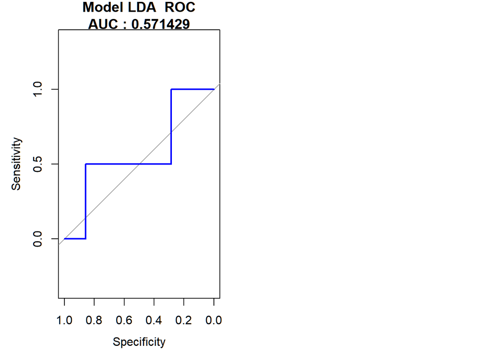

```r
plot(model.lda.roc, legacy_axes = TRUE, col = "blue", main = paste0("Model LDA  ROC",
    "\n", "AUC : ", model.lda.auc))


metricmodel <- cbind(metricmodel, metric.lda[])
```

### Model : SVM With Radial Kernel

```r
traincolor.svm <- traincolordata

model.svmr <- svm(label ~ ., traincolor.svm, cost = 20, cross = 10, type = "C-classification",
    kernel = "radial")

summary(model.svmr)
```

```
##
## Call:
## svm(formula = label ~ ., data = traincolor.svm, cost = 20, cross = 10,
##     type = "C-classification", kernel = "radial")
##
##
## Parameters:
##    SVM-Type:  C-classification
##  SVM-Kernel:  radial
##        cost:  20
##
## Number of Support Vectors:  22
##
##  ( 10 12 )
##
##
## Number of Classes:  2
##
## Levels:
##  BLACK BLUE
##
## 10-fold cross-validation on training data:
##
## Total Accuracy: 44
## Single Accuracies:
##  100 66.66667 100 0 50 0 0 66.66667 0 66.66667
```

```r
model.svmr.predtest <- predict(model.svmr, newdata = testcolordata)

# Confusion Matrix For Model SVM

model.svmr.cfmat <- table(Predicted = model.svmr.predtest, Actual = testcolordata$label)

metric.svmr <- perfmetric(model.svmr.cfmat)
```

```
##          Actual
## Predicted BLACK BLUE
##     BLACK     6    1
##     BLUE      1    3
```

**Plotting the ROC curve for Model MODEL.SVM Radial Kernel**

```r
model.svmr.roc <- roc(response = testcolordata$label, predictor = as.numeric(model.svmr.predtest))
model.svmr.auc <- round(auc(model.svmr.roc), 6)
par(mfrow = c(1, 2))
pander(ftable(model.svmr.cfmat))
```

|  | Actual | BLACK | BLUE |
| --- | --- | --- | --- |
| Predicted |  |  |  |
| BLACK |  | 6 | 1 |
| BLUE |  | 1 | 3 |

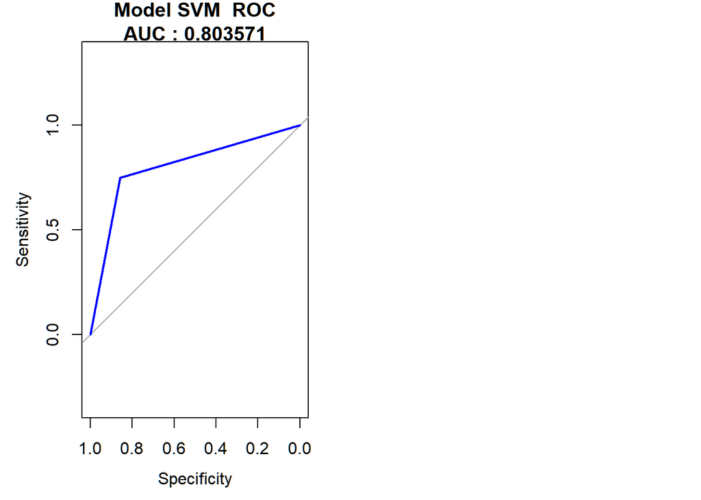

```r
plot(model.svmr.roc, legacy_axes = TRUE, col = "blue", main = paste0("Model SVM  ROC",
    "\n", "AUC : ", model.svmr.auc))


metricmodel <- cbind(metricmodel, metric.svmr[])
```

### Model : Decision Tree

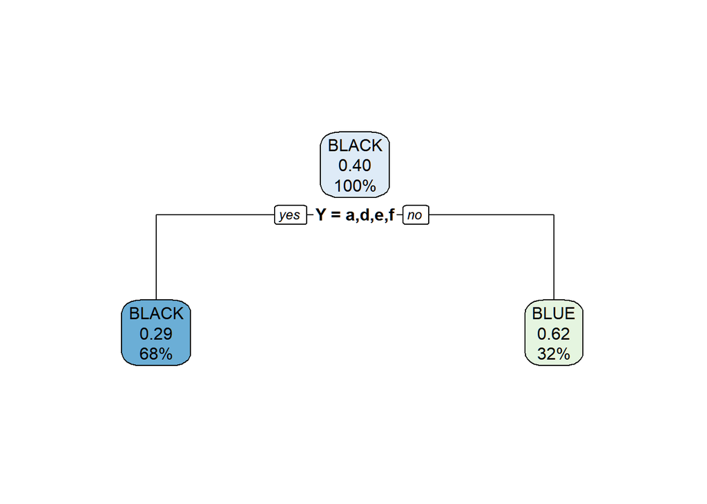

```r
traincolor.tree <- traincolordata

model.tree <- rpart(label ~ ., traincolor.tree, method = "class")

rpart.plot(model.tree)
```

```r
summary(model.tree)
```

```
## Call:
## rpart(formula = label ~ ., data = traincolor.tree, method = "class")
##   n= 25
##
##     CP nsplit rel error xerror      xstd
## 1 0.20      0       1.0    1.0 0.2449490
## 2 0.01      1       0.8    1.9 0.2135416
##
## Variable importance
##   Y
## 100
##
## Node number 1: 25 observations,    complexity param=0.2
##   predicted class=BLACK  expected loss=0.4  P(node) =1
##     class counts:    15    10
##    probabilities: 0.600 0.400
##   left son=2 (17 obs) right son=3 (8 obs)
##   Primary splits:
##       Y splits as  LRRLLL, improve=1.1911760, (0 missing)
##       X < 27 to the right, improve=0.3333333, (0 missing)
##
## Node number 2: 17 observations
##   predicted class=BLACK  expected loss=0.2941176  P(node) =0.68
##     class counts:    12     5
##    probabilities: 0.706 0.294
##
## Node number 3: 8 observations
##   predicted class=BLUE   expected loss=0.375  P(node) =0.32
##     class counts:     3     5
##    probabilities: 0.375 0.625
```

```r
model.tree.probtest <- predict(model.tree, newdata = testcolordata, type = "prob")
model.tree.probtest <- as.data.frame(model.tree.probtest)$BLUE

model.tree.predtest <- ifelse(model.tree.probtest > 0.5, "BLUE", "BLACK")


# Confusion Matrix For Model Tree

model.tree.cfmat <- table(Predicted = model.tree.predtest, Actual = testcolordata$label)

metric.tree <- perfmetric(model.tree.cfmat)
```

```
##          Actual
## Predicted BLACK BLUE
##     BLACK     5    2
##     BLUE      2    2
```

**Plotting the ROC curve for Model MODEL.TREE**

```r
model.tree.roc <- roc(label ~ model.tree.probtest, data = testcolordata)
model.tree.auc <- round(auc(model.tree.roc), 6)


par(mfrow = c(1, 2))

pander(ftable(model.tree.cfmat))
```

|  | Actual | BLACK | BLUE |
| --- | --- | --- | --- |
| Predicted |  |  |  |
| BLACK |  | 5 | 2 |
| BLUE |  | 2 | 2 |

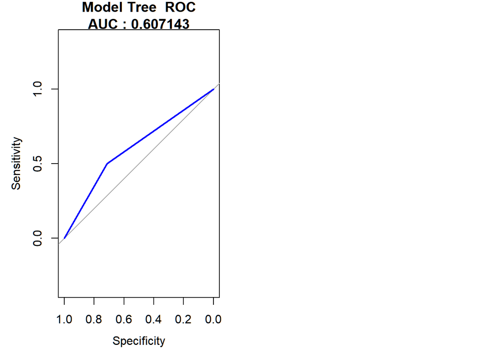

```r
plot(model.tree.roc, legacy_axes = TRUE, col = "blue", main = paste0("Model Tree  ROC",
    "\n", "AUC : ", model.tree.auc))


metricmodel <- cbind(metricmodel, metric.tree[])
```

### Model : kNN

As with kNN the eucledian distance is measured, the features neeed to be numeric . Hence we convert the Y predictors into numeric

```r
traincolor.knn <- traincolordata
testcolor.knn <- testcolordata

traincolor.knn$Y <- apply(as.data.frame(traincolor.knn$Y), 1, utf8ToInt)
testcolor.knn$Y <- apply(as.data.frame(testcolor.knn$Y), 1, utf8ToInt)


model.knn <- knn(traincolor.knn[, 1:2], testcolor.knn[, 1:2], cl = traincolor.knn$label,
    k = 10, prob = TRUE)

summary(model.knn)
```

```
## BLACK  BLUE
##    10     1
```

```r
model.knn.probtest <- attr(model.knn, "prob")
model.knn.predtest <- ifelse(model.knn == "BLUE", model.knn.probtest, 1 - model.knn.probtest)


# Confusion Matrix For Model kNN


model.knn.cfmat <- table(Predicted = model.knn, Actual = testcolor.knn$label)

metric.knn <- perfmetric(model.knn.cfmat)
```

```
##          Actual
## Predicted BLACK BLUE
##     BLACK     7    3
##     BLUE      0    1
```

```r
model.knn.roc <- roc(label ~ model.knn.probtest, data = testcolor.knn)
model.knn.auc <- round(auc(model.knn.roc), 6)


par(mfrow = c(1, 2))

pander(ftable(model.knn.cfmat))
```

|  | Actual | BLACK | BLUE |
| --- | --- | --- | --- |
| Predicted |  |  |  |
| BLACK |  | 7 | 3 |
| BLUE |  | 0 | 1 |

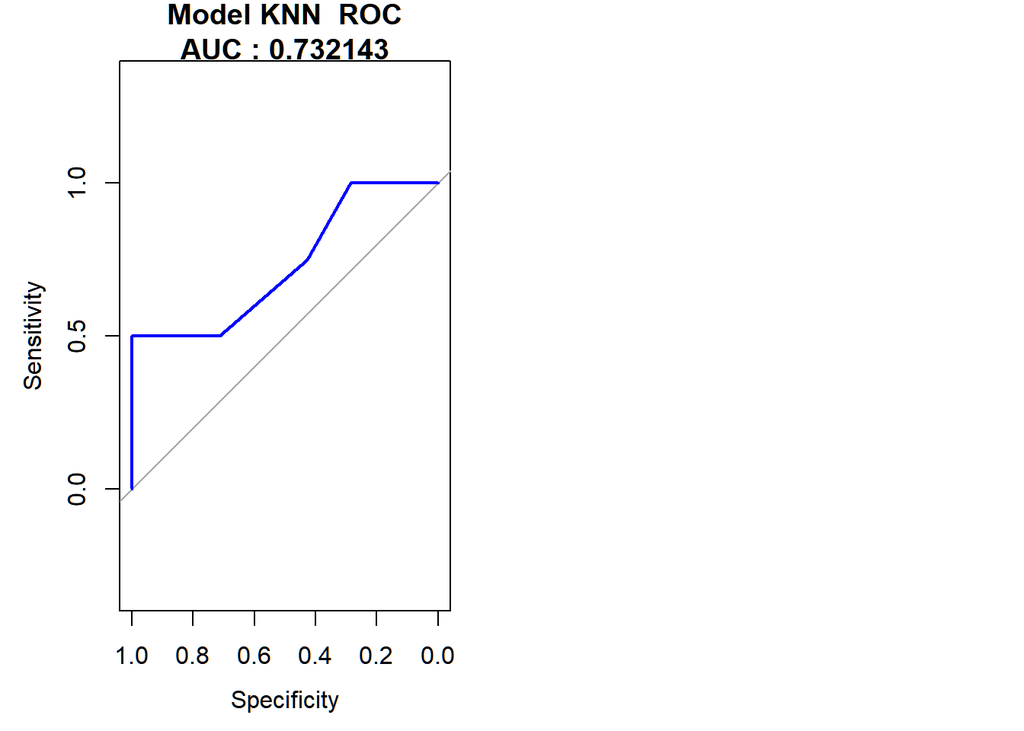

```r
plot(model.knn.roc, legacy_axes = TRUE, col = "blue", main = paste0("Model KNN  ROC",
    "\n", "AUC : ", model.knn.auc))

metricmodel <- cbind(metricmodel, metric.knn[])
```

### Model Metrics

```r
metricmodel <- rbind(metricmodel, c(model.logistic.auc, model.nb.auc, model.lda.auc,
    model.svmr.auc, model.tree.auc, model.knn.auc))

rownames(metricmodel) <- c("Sensitivity", "FPR", "Specificity", "ErrorRate", "Accuracy",
    "AUC")
colnames(metricmodel) <- c("Logistic", "NB", "LDA", "SVM_Radial", "Tree", "knn")

pander(metricmodel, caption = "Models Performance Metrics : BLUE Positive")
```

Models Performance Metrics : BLUE Positive

|  | Logistic | NB | LDA | SVM_Radial | Tree | knn |
| --- | --- | --- | --- | --- | --- | --- |
| **Sensitivity** | 0.6667 | 0.6667 | 0.6667 | 0.75 | 0.5 | 1 |
| **FPR** | 0.25 | 0.25 | 0.25 | 0.1429 | 0.2857 | 0.3 |
| **Specificity** | 0.75 | 0.75 | 0.75 | 0.8571 | 0.7143 | 0.7 |
| **ErrorRate** | 0.2727 | 0.2727 | 0.2727 | 0.1818 | 0.3636 | 0.2727 |
| **Accuracy** | 0.7273 | 0.7273 | 0.7273 | 0.8182 | 0.6364 | 0.7273 |
| **AUC** | 0.5714 | 0.6071 | 0.5714 | 0.8036 | 0.6071 | 0.7321 |

### Conclusions And Classifier performance

However we keep in mind that the data at hand was very limited and the samples derived were less . More data could help with better models.

SVM performs well for higher dimensions lesser training data and hence we may see the better accuracy here , with good TPR rates.

Logistic Regression doesnot do that well for non linear solutions a, however we dont see a very bad performance here , may be due to the less data. Similarly Naive Bayes is more of linear classifier which assumes conditional independance Decision Trees usuallly are better at accuracy compared to linear solutions like Logistic and better at handling collinearity